# naglu 3 month behaviour

Karissa

14/07/2021

## setup

```r
library(tidyverse)
library(readxl)
library(here)
library(magrittr)
library(scales)
library(readxl)
library(ggpubr)
library(ggeasy)
library(ggfortify)
library(ggbeeswarm)
library(ggforce)
library(kableExtra)

# stat analysis
library(broom)
library(lme4)
library(performance)
library(car)
library(emmeans)
library(glmmTMB)
library(MASS)

# set the default theme for ggplot as theme_bw
theme_set(theme_bw())

# read in Ewans metadata speadsheet. make all the metadata as factors as well
meta <-
  read_excel("naglu 3 month behavioural metadata.xlsx") %>%
  dplyr::rename(
    fish_id = 1,
    Tank = `Tank/Lay`,
    Keep = `Keep (yes, no, maybe`
  ) %>%
  mutate(
    fish_id = as.factor(fish_id),
    Day = case_when(# there is probably a nicer way to do this but oh well.
      Day == "30.6.21" ~ "Day 1",
      Day == "1.7.21" ~ "Day 2",
      Day == "2.7.21" ~ "Day 3",
      Day == "3.7.21" ~ "Day 4",
      Day == "4.7.21" ~ "Day 5",
      Day == "5.7.21" ~ "Day 6",
      Day == "6.7.21" ~ "Day 7",
      Day == "7.7.21" ~ "Day 8",
      Day == "8.7.21" ~ "Day 9",
      Day == "9.7.21" ~ "Day 10",
      Day == "10.7.21" ~ "Day 11",
      Day == "11.7.21" ~ "Day 12",
      Day == "12.7.21" ~ "Day 13",
      Day == "13.7.21" ~ "Day 14"
    ) %>%
      as.factor(),
    Time = as.factor(Time),
    Tank = as.factor(Tank),
    Sex = as.factor(Sex),
    Genotype = factor(Genotype, levels = c("wt", "het", "hom"))
  )
# prepare the final data object which contains genotype
final_data <- read_csv("naglu_3m_final_output.csv") %>%
  dplyr::select(-1) %>%
  mutate(fish_id = factor(fish_id)) %>%
  left_join(meta) %>%
  dplyr::filter(Keep == "Y")

# make an object which converts the final data to long format. for easier plotting in ggplot
final_data_long <- final_data %>%
  dplyr::filter(Keep == "Y") %>%
  gather(key = "tetras", value = "Count", # convert to long format
         grep("[L|R]{4}",
              colnames(.))
         )

# also make an object which sums the tetragrams over the hour
final_data_summedoverbins <- final_data %>%
  gather(key = "tetras", value = "Count", # convert to long format
         grep("[L|R]{4}", # select the columns which contain a L or a R four times
              colnames(.))
         ) %>%
  group_by(fish_id, tetras) %>%
  mutate(x = sum(Count)) %>% # sum the tetragram counts per fish_id
  dplyr::select(colnames(meta), tetras, x) %>%
  unique
```

# Introduction

In this analysis, I will analyse Ewans raw data generated for zebrafish arising from a lay from the same *naglu* A603fs het x het parents in the Zantiks Y-maze.

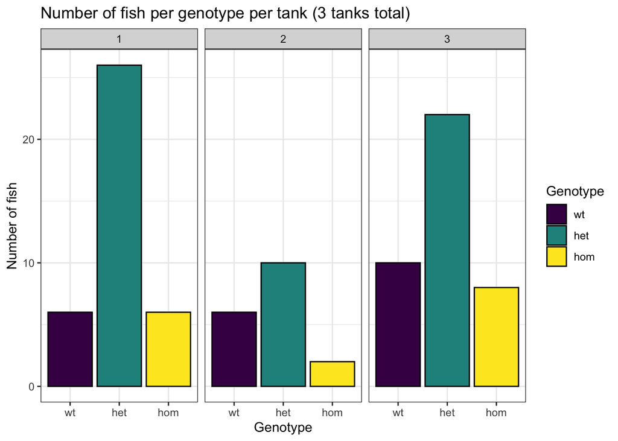

```r
meta %>%
  group_by(Tank, Genotype) %>%
  summarise(n = n()) %>%
  ggplot(aes(x = Genotype, y = n, fill = Genotype)) +
  geom_col(colour = "black") +
  facet_wrap(~Tank) +
  scale_fill_viridis_d() +
  labs(y = "Number of fish") +
  ggtitle("Number of fish per genotype per tank (3 tanks total)")
```

Fish were isolated for 30 mins two at a time, then placed in the maze for 1 hour. Raw data was collected, and metadata was recorded (i.e. sex, time, day). These raw data spreadsheets were batch processed in the naglu 3, BatchProcess R script to produce the `final_data` object. This object contains the tetragram frequencies (see below). Note that fish were genotyped after data collection so that we are blinded from any observer bias until after raw data collection. Addiotianlly, the videos were manually observed to ensure proper tracking. Any fish where the tracking was not perfect was omitted.

```r
 read_csv("Raw qwer files/Day 1 - 30.6.21/qwer-20210630T014606.csv", skip =4, col_names = F) %>%
  head %>%
  dplyr::select(-X2, -X3) %>%
  set_colnames(c("Time", "fish",'enter or exit', "zone")) %>%
  kable(caption = "example of raw data") %>%
  kable_styling(full_width = F)
```

example of raw data

| Time | fish | enter or exit | zone |
| --- | --- | --- | --- |
| 000:00:30.551 | 1 | Enter_Zone | 2 |
| 000:00:30.551 | 2 | Enter_Zone | 1 |
| 000:00:30.784 | 2 | Exit_Zone | 1 |
| 000:00:30.784 | 2 | Enter_Zone | 4 |
| 000:00:32.883 | 1 | Exit_Zone | 2 |
| 000:00:32.883 | 1 | Enter_Zone | 4 |

```r
final_data %>%
  head %>%
  kable(caption = "Example of the processed data") %>%
  kable_styling()
```

Example of the processed data

| fish_id | bin | LLLL | LLLR | LLRL | LLRR | LRLL | LRLR | LRRL | LRRR | RLLL | RLLR | RLRL | RLRR | RRLL | RRLR | RRRL | RRRR | L | R | total_turns | reps | alts | rel_reps | rel_alts | rel_R | rel_L | Day | Time | Sex | … |
| --- | --- | --- | --- | --- | --- | --- | --- | --- | --- | --- | --- | --- | --- | --- | --- | --- | --- | --- | --- | --- | --- | --- | --- | --- | --- | --- | --- | --- | --- | --- |
| 1 | 1 | 1 | 3 | 3 | 5 | 4 | 6 | 6 | 7 | 4 | 5 | 7 | 8 | 4 | 9 | 7 | 11 | 38 | 55 | 93 | 12 | 13 | 12.903226 | 13.97849 | 59.13978 | 40.86022 | Day 1 | 10.15 | M | … |
| 1 | 2 | 13 | 4 | 4 | 3 | 3 | 5 | 2 | 5 | 4 | 2 | 5 | 4 | 3 | 4 | 5 | 9 | 41 | 37 | 78 | 22 | 10 | 28.205128 | 12.82051 | 47.43590 | 52.56410 | Day 1 | 10.15 | M | … |
| 1 | 3 | 2 | 1 | 1 | 1 | 1 | 2 | 3 | 2 | 1 | 1 | 2 | 4 | 1 | 4 | 3 | 3 | 14 | 21 | 35 | 5 | 4 | 14.285714 | 11.42857 | 60.00000 | 40.00000 | Day 1 | 10.15 | M | … |
| 1 | 4 | 4 | 5 | 6 | 3 | 3 | 5 | 2 | 3 | 5 | 4 | 2 | 3 | 5 | 0 | 3 | 0 | 32 | 24 | 56 | 4 | 7 | 7.142857 | 12.50000 | 42.85714 | 57.14286 | Day 1 | 10.15 | M | … |
| 1 | 5 | 7 | 4 | 1 | 2 | 1 | 1 | 1 | 2 | 3 | 0 | 1 | 1 | 2 | 1 | 2 | 0 | 21 | 11 | 32 | 7 | 2 | 21.875000 | 6.25000 | 34.37500 | 65.62500 | Day 1 | 10.15 | M | … |
| 1 | 6 | 0 | 0 | 2 | 2 | 1 | 6 | 5 | 1 | 0 | 3 | 5 | 4 | 2 | 4 | 1 | 0 | 18 | 21 | 39 | 0 | 11 | 0.000000 | 28.20513 | 53.84615 | 46.15385 | Day 1 | 10.15 | M | … |

# check genotype proportions

First, I will check that genotype proportions are as expected. A few less homozygous fish are observed than expected. However, this is partly due to that they were omitted because the software did not track properly.

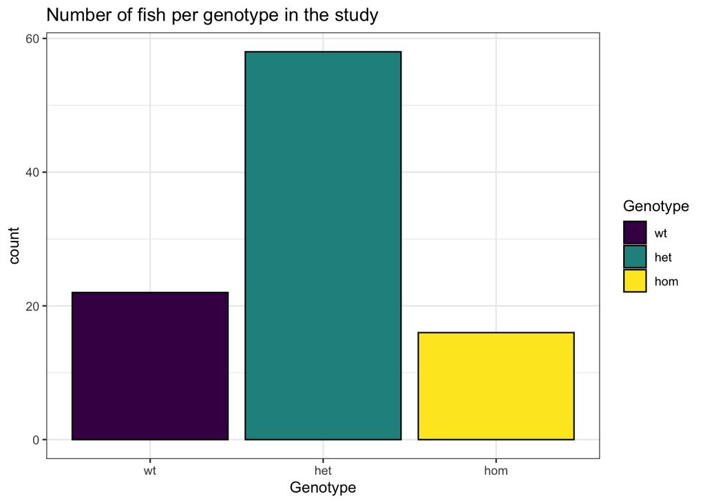

```r
meta %>%
  ggplot(aes(Genotype, fill = Genotype)) +
  geom_bar(colour = "black") +
  scale_fill_viridis_d() +
  ggtitle("Number of fish per genotype in the study")
```

```r
  # ggsave("naglu 3m plots/fishpergeno.png", width = 10, height = 10, units = "cm", dpi = 200, scale = 1.4)
```

# Visualisation of raw data

The plots below show the raw counts of each of the possible tetragrams. We can see some fish were quite inactive, wih low total number of tetragrams. The plot below show fish 1-10 for vis purposes. To see all fish, remove the `dplyr::filter` line of code.

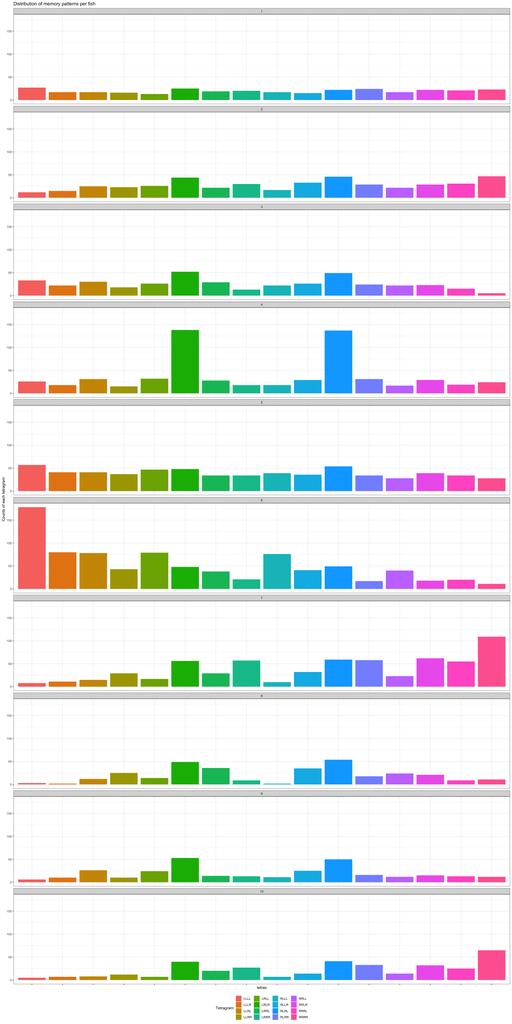

```r
final_data_summedoverbins %>%
  dplyr::filter(fish_id %in% c(seq(1,10))) %>%
  ggplot(aes(x = tetras, y = x, fill = tetras)) +
  geom_col() +
  facet_wrap(~fish_id, ncol = 1) +
  labs(y = "Counts of each tetragram",
       fill = "Tetragram") +
  theme(axis.text.x = element_blank(),
        legend.position = "bottom") +
  ggtitle("Distribution of memory patterns per fish")
```

Cleal et al. showed that zebrafish naturally perform more of the alternation tetragrams (LRLR and RLRL) in a Y-maze. This is also obsevred in our data here.

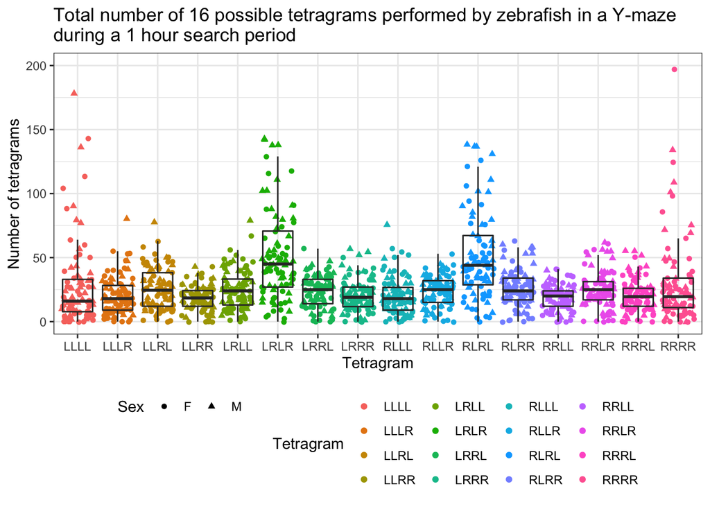

```r
final_data_summedoverbins %>%
  dplyr::distinct(x, .keep_all = T) %>%
  ggplot(aes(x = tetras, y = x)) +
  geom_jitter(aes(colour = tetras,
                  shape = Sex)) +
  geom_boxplot(outlier.shape = NA,
               # aes(fill = Genotype)
               fill = NA
               ) +
  scale_fill_viridis_d() +
  coord_cartesian(ylim = c(0,200)) + # zoom in
  labs(y = "Number of tetragrams",
       colour = "Tetragram",
       x = "Tetragram")+
  theme(legend.position = "bottom")  +
  ggtitle("Total number of 16 possible tetragrams performed by zebrafish in a Y-maze\nduring a 1 hour search period")
```

```r
  #ggsave("naglu 3m plots/tetrasnaglunogeno.png", width = 20, height = 10, units = "cm", dpi = 200, scale = 1.4)
```

We can also overlay the genotype boxplots as shown below. Looks like the heterozyous and homozygous fish perform more alternations than the WT fish. I will look into this more later in the analysis

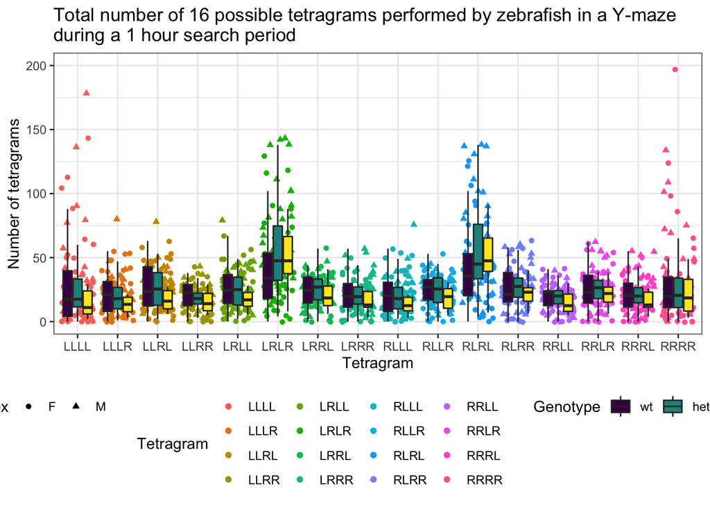

```r
final_data_summedoverbins %>%
  dplyr::distinct(x, .keep_all = T) %>%
  ggplot(aes(x = tetras, y = x)) +
  geom_jitter(aes(colour = tetras,
                  shape = Sex)) +
  geom_boxplot(outlier.shape = NA,
               aes(fill = Genotype) # fill the boxplots by genotype
               ) +
  scale_fill_viridis_d() +
  coord_cartesian(ylim = c(0,200)) + # zoom in
  labs(y = "Number of tetragrams",
       colour = "Tetragram",
       x = "Tetragram")+
  theme(legend.position = "bottom")  +
  ggtitle("Total number of 16 possible tetragrams performed by zebrafish in a Y-maze\nduring a 1 hour search period")
```

The alternation tetragrams are the tetragram of interest (the measure of working memory). Below indicates the number of tetragrams performed by zerbafish across the 6 x 10 min blocks of the hour they spent in the maze.

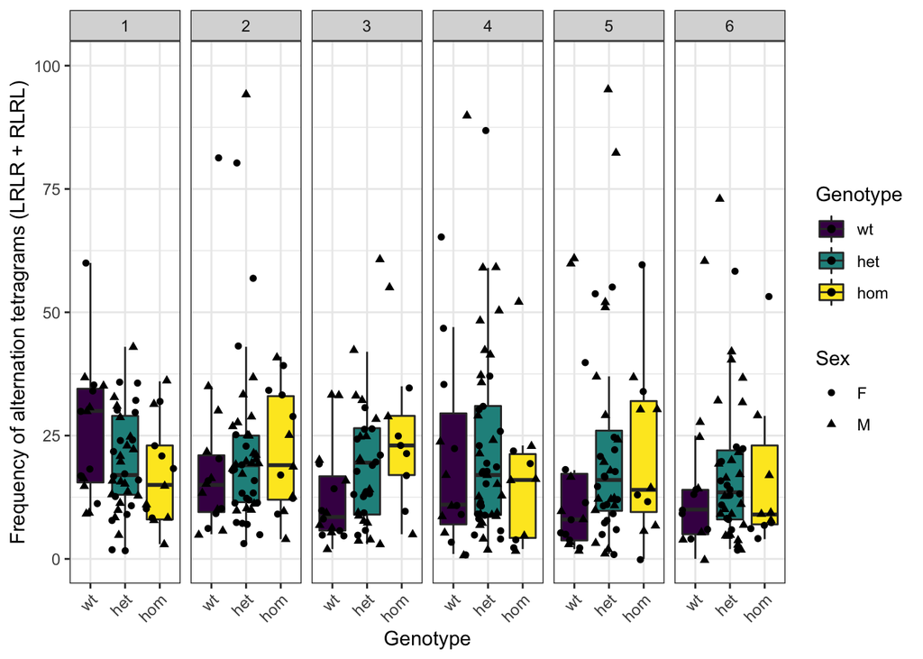

```r
final_data_long %>%
  dplyr::distinct(rel_alts, .keep_all = T) %>%
  ggplot(aes(x = Genotype, y = alts, fill = Genotype)) +
  geom_boxplot(outlier.shape = NA) +
  geom_jitter(aes(shape = Sex)) +
  facet_wrap(~bin, nrow = 1) +
  theme(axis.text.x  = element_text(angle = 45, hjust = 1, vjust = 1)) +
  ylab("Frequency of alternation tetragrams (LRLR + RLRL)") +
  coord_cartesian(ylim = c(0, 100)) + # zoom in
  scale_fill_viridis_d()
```

We can also display this as the *relative* amount of alternation tetragrams performed by zebrafish in a 1 hour search period. This will control for how active each fish is.

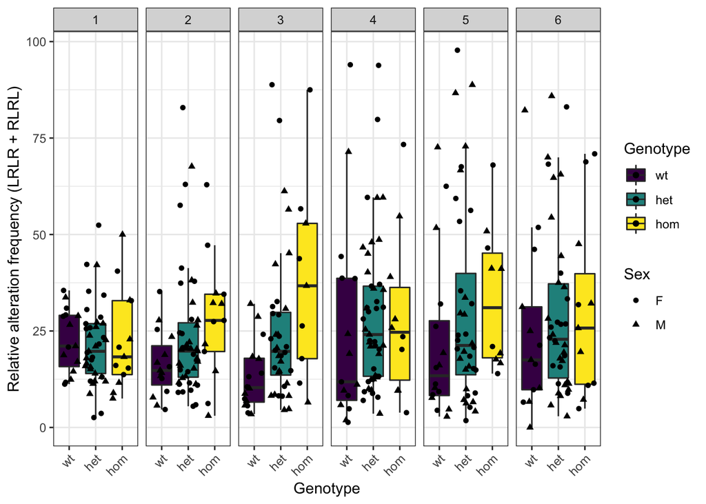

```r
final_data_long %>%
  dplyr::distinct(rel_alts, .keep_all = T) %>%
  ggplot(aes(x = Genotype, y = rel_alts, fill = Genotype)) +
  geom_boxplot(outlier.shape = NA) +
  geom_jitter(aes(shape = Sex)) +
  facet_wrap(~bin, nrow = 1) +
  ylab("Relative alteration frequency (LRLR + RLRL)") +
  theme(axis.text.x  = element_text(angle = 45, hjust = 1, vjust = 1))  +
  scale_fill_viridis_d()
```

# Locomotor defect

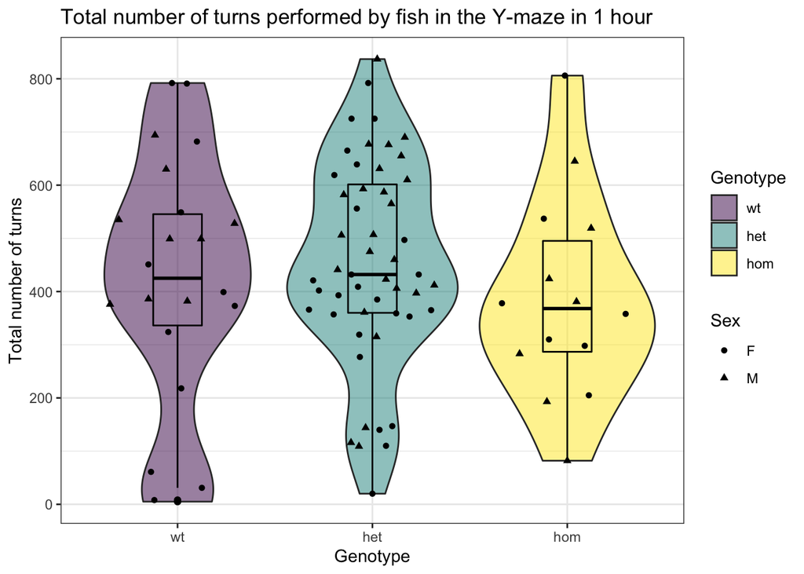

```r
final_data_summedoverbins %>%
  ungroup() %>%
  group_by(fish_id) %>%
  mutate(total_turns = sum(x)) %>%
  dplyr::select(colnames(meta), total_turns) %>%
  unique %>%
  dplyr::filter(total_turns < 1000) %>%
  ggplot(aes(x = Genotype,y = total_turns)) +
  geom_violin(aes(fill = Genotype),
               alpha = 0.5) +
  geom_boxplot(aes(colour = Genotype),
               fill = NA,
               width = 0.25,
               colour= "black") +
  geom_quasirandom(aes(shape = Sex)) +
  scale_fill_viridis_d(option = "viridis") +
  scale_colour_viridis_d(option = "viridis") +
  ylab("Total number of turns") +
  ggtitle("Total number of turns performed by fish in the Y-maze in 1 hour")
```

```r
  #ggsave("naglu 3m plots/totalturnsnaglu.png", width = 10, height = 10, units = "cm", dpi = 200, scale = 1.4)

final_data_summedoverbins %>%
  ungroup() %>%
  group_by(fish_id) %>%
  mutate(total_turns = sum(x)) %>%
  dplyr::select(colnames(meta), total_turns) %>%
  unique %>%
  glm.nb(total_turns ~ Genotype + Sex + Tank,
         data = .) %>%
  summary %>%
  .$coef %>%
  kable(caption = "Negative binomial GLM model coefficients.
        None of the factors have a significant effect on the total number of turns" ) %>%
  kable_styling()
```

Negative binomial GLM model coefficients. None of the factors have a significant effect on the total number of turns

|  | Estimate | Std. Error | z value | Pr(>\|z\|) |
| --- | --- | --- | --- | --- |
| (Intercept) | 5.8179383 | 0.1841093 | 31.6004512 | 0.0000000 |
| Genotypehet | 0.1704605 | 0.1695381 | 1.0054408 | 0.3146846 |
| Genotypehom | -0.0615894 | 0.2250886 | -0.2736231 | 0.7843743 |
| SexM | 0.0983695 | 0.1431880 | 0.6869951 | 0.4920858 |
| Tank2 | 0.2257252 | 0.2069067 | 1.0909517 | 0.2752942 |
| Tank3 | 0.2372386 | 0.1548273 | 1.5322790 | 0.1254536 |

### time spent in each zone of the Y-maze

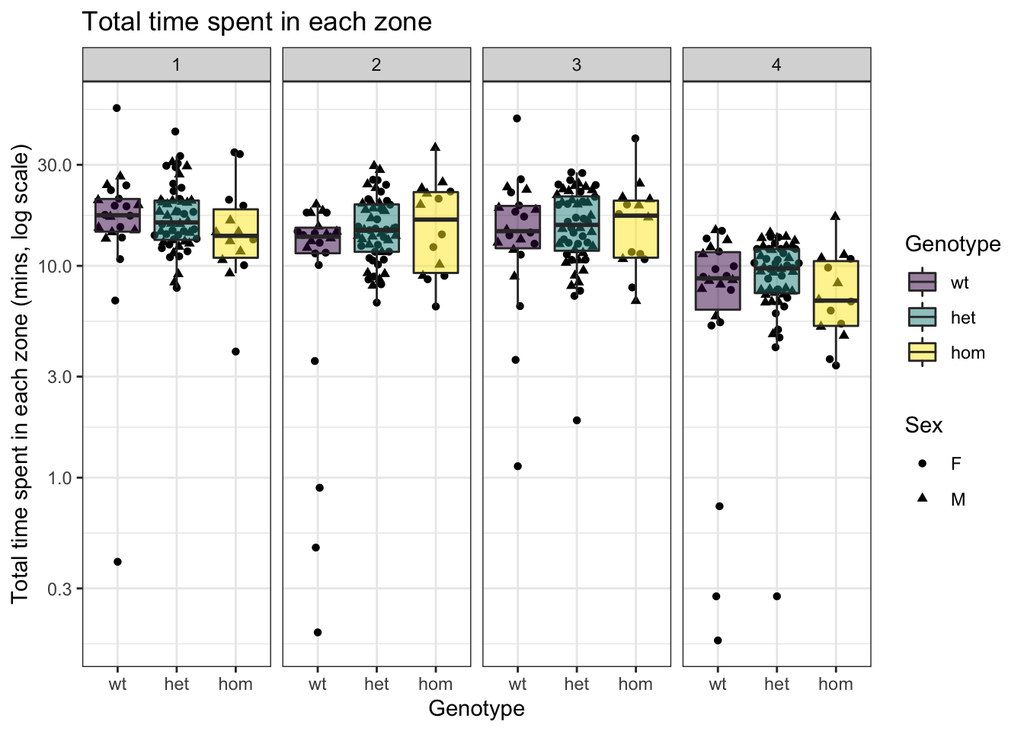

```r
read_csv("naglu_3m_time_in_zone.csv") %>%
  mutate(fish_id = as.character(fish_id)) %>%
  dplyr::select(fish_id, bin, zone, time_in_zone) %>%
  left_join(meta) %>%
  dplyr::filter(Keep == "Y") %>%
  group_by(fish_id, zone) %>%
  mutate(total_timeInZone = sum(time_in_zone)) %>%
  dplyr::distinct(total_timeInZone, .keep_all = TRUE) %>%
  ggplot(aes(x = Genotype, y = total_timeInZone/60)) +
  geom_quasirandom(aes(shape=Sex)
                  ) +
  geom_boxplot(aes(fill = Genotype),
               outlier.shape = NA,
                alpha = 0.5) +
  facet_wrap(~zone, nrow = 1) +
  scale_y_log10() +
  ylab("Total time spent in each zone (mins, log scale)") +
  scale_fill_viridis_d() +
  ggtitle("Total time spent in each zone")
```

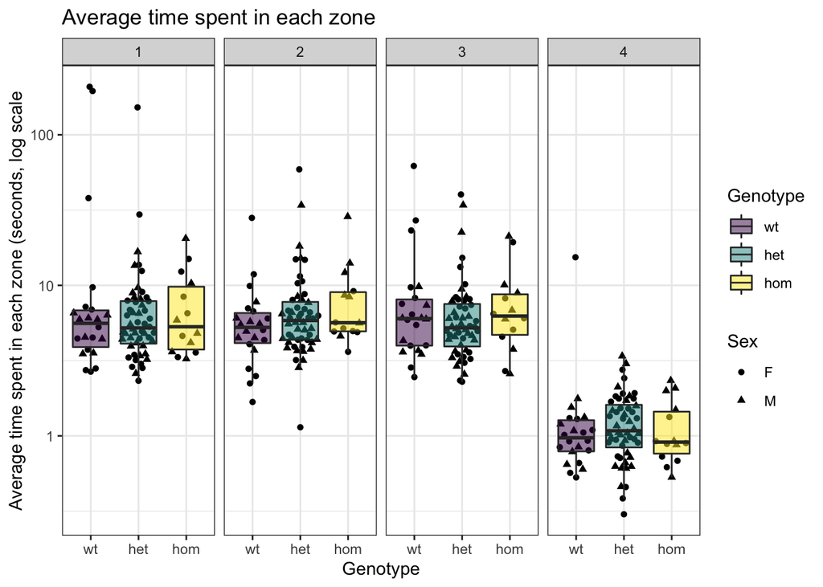

```r
  #ggsave("naglu 3m plots/totalttimInZonenaglu.png", width = 10, height = 10, units = "cm", dpi = 200, scale = 1.4)


read_csv("naglu_3m_time_in_zone.csv") %>%
  mutate(fish_id = as.character(fish_id)) %>%
  dplyr::select(fish_id, bin, zone, time_in_zone) %>%
  left_join(meta) %>%
  dplyr::filter(Keep == "Y") %>%
  group_by(fish_id, zone) %>%
  mutate(aveTimeInZone = mean(time_in_zone)) %>%
  dplyr::distinct(aveTimeInZone, .keep_all = TRUE) %>%
  ggplot(aes(x = Genotype, y = aveTimeInZone)) +
  geom_quasirandom(aes(shape=Sex)
                  ) +
  geom_boxplot(aes(fill = Genotype),
               outlier.shape = NA,
                alpha = 0.5) +
  facet_wrap(~zone, nrow = 1) +
  scale_fill_viridis_d() +
  scale_y_log10() +
  ylab("Average time spent in each zone (seconds, log scale") +
  ggtitle("Average time spent in each zone")
```

```r
  #ggsave("naglu 3m plots/Averagetimeinzone.png", width = 10, height = 10, units = "cm", dpi = 200, scale = 1.4)

read_csv("naglu_3m_time_in_zone.csv") %>%
  mutate(fish_id = as.character(fish_id)) %>%
  dplyr::select(fish_id, bin, zone, time_in_zone) %>%
  left_join(meta) %>%
  dplyr::filter(Keep == "Y") %>%
  group_by(fish_id, zone) %>%
  mutate(aveTimeInZone = mean(time_in_zone)) %>%
  dplyr::distinct(aveTimeInZone, .keep_all = TRUE) %>%
  lm(log(aveTimeInZone) ~ (Genotype + zone)^2 + Sex,
    data = .) %>%
  summary %>%
  .$coef %>%
  kable(caption = "linear model: log(aveTimeInZone) ~ (Genotype + zone)^2 + Sex") %>%
  kable_styling()
```

linear model: log(aveTimeInZone) ~ (Genotype + zone)^2 + Sex

|  | Estimate | Std. Error | t value | Pr(>\|t\|) |
| --- | --- | --- | --- | --- |
| (Intercept) | 2.8314221 | 0.2155512 | 13.1357265 | 0.0000000 |
| Genotypehet | -0.1425544 | 0.2536695 | -0.5619691 | 0.5745020 |
| Genotypehom | 0.0230028 | 0.3409784 | 0.0674611 | 0.9462537 |
| zone | -0.5553728 | 0.0776232 | -7.1547250 | 0.0000000 |
| SexM | -0.0864184 | 0.0871847 | -0.9912106 | 0.3222774 |
| Genotypehet:zone | 0.0450498 | 0.0925989 | 0.4865043 | 0.6269186 |
| Genotypehom:zone | 0.0061305 | 0.1244741 | 0.0492510 | 0.9607477 |

# check for handedness

Fontana et al. (https://doi.org/10.1007/s10071-019-01296-9, Matt Parker’s group) showed that fish sometimes show a behavioural lateralisation (i.e. handedness). If fish show this, then they would perform less alternation tetragrams not due to working memory.

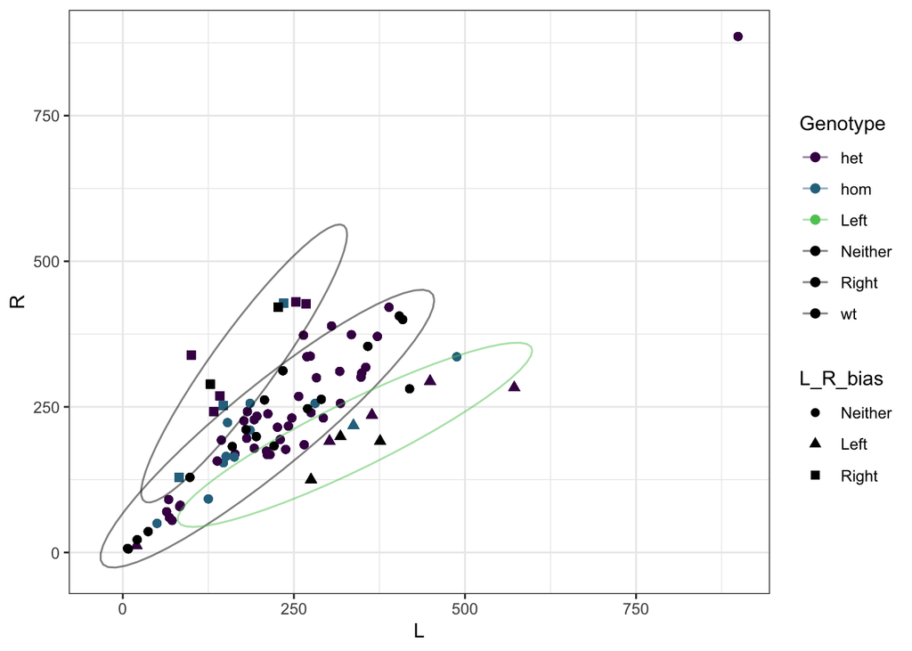

```r
# make the LR bias object
LR_Bias <- final_data %>%
  dplyr::select(L, R, total_turns, fish_id) %>%
  group_by(fish_id) %>%
  mutate(L = sum(L),
         R = sum(R),
         total_turns = sum(total_turns),
         L_R_bias = case_when( #consider more than 60% of the time performing a left or right turn to be a bias
           L/total_turns > 0.6 ~ "Left",
           R/total_turns > 0.6 ~ "Right",
           TRUE ~ "Neither"
         )) %>%
  dplyr::select(fish_id, L_R_bias) %>%
  unique() %>%
  mutate(L_R_bias = factor(L_R_bias,
                           levels = c("Neither", "Left", "Right"))
  )

final_data %>%
  left_join(LR_Bias) %>%
  group_by(fish_id) %>%
  mutate(L = sum(L),
         R = sum(R),
         total_turns = sum(total_turns)
  ) %>%
  ggplot(aes(L, R, colour = Genotype)) +
  geom_point(aes(shape = L_R_bias),
             size = 2) +
  stat_ellipse(aes(colour = L_R_bias), alpha = 0.5) +
  scale_color_manual(values = c(viridis_pal(end=0.75)(3),
                               rep("black", 3))
  )
```